# BasicGraphAssignment

```python
%matplotlib inline
import matplotlib.pyplot as plt
import pandas as pd
```

```python
df_op = pd.read_csv('OpidsVA.csv')
```

```python
df_op
```

|  | FIPSCode | CountyName | FFHO-Rate | FPOO-Rate | HIV-Rate | MedianHouseholdIncome |
| --- | --- | --- | --- | --- | --- | --- |
| 0 | 51001 | Accomack | 12.1 | 12.1 | 3.0 | 39040 |
| 1 | 51003 | Albemarle | 0.9 | 0.9 | 2.8 | 73132 |
| 2 | 51005 | Alleghany | 6.4 | 12.8 | 6.4 | 47037 |
| 3 | 51007 | Amelia | 7.7 | 0.0 | 7.7 | 56172 |
| 4 | 51009 | Amherst | 3.2 | 6.3 | 6.3 | 46497 |
| ... | ... | ... | ... | ... | ... | ... |
| 128 | 51800 | Suffolk | 4.5 | 4.5 | 15.7 | 65025 |
| 129 | 51810 | Virginia Beach | 12.4 | 6.4 | 13.9 | 70596 |
| 130 | 51820 | Waynesboro | 0.0 | 0.0 | 4.6 | 41255 |
| 131 | 51830 | Williamsburg | 13.1 | 0.0 | 6.6 | 49231 |
| 132 | 51840 | Winchester | 29.1 | 14.5 | 7.3 | 46093 |

133 rows × 6 columns

```python
df_op.describe()
```

|  | FIPSCode | FFHO-Rate | FPOO-Rate | HIV-Rate | MedianHouseholdIncome |
| --- | --- | --- | --- | --- | --- |
| count | 133.000000 | 133.000000 | 133.000000 | 133.000000 | 133.000000 |
| mean | 51263.992481 | 7.596992 | 6.045113 | 7.708271 | 55601.526316 |
| std | 271.883038 | 8.539063 | 6.754880 | 9.578520 | 19707.501510 |
| min | 51001.000000 | 0.000000 | 0.000000 | 0.000000 | 30587.000000 |
| 25% | 51069.000000 | 0.000000 | 0.000000 | 0.000000 | 41255.000000 |
| 50% | 51139.000000 | 5.700000 | 4.400000 | 5.300000 | 49935.000000 |
| 75% | 51550.000000 | 12.800000 | 9.000000 | 10.500000 | 66170.000000 |
| max | 51840.000000 | 31.400000 | 40.100000 | 57.000000 | 134609.000000 |

```python
df_op.columns
```

```
Index(['FIPSCode', 'CountyName', 'FFHO-Rate', 'FPOO-Rate', 'HIV-Rate',
       'MedianHouseholdIncome'],
      dtype='object')
```

```python
df_op.columns.values
```

```
array(['FIPSCode', 'CountyName', 'FFHO-Rate', 'FPOO-Rate', 'HIV-Rate',
       'MedianHouseholdIncome'], dtype=object)
```

### Do opioid overdoes tend to be associated with less affluent areas—that is, areas where families have lower incomes?

Yes, there appears to be a negative relationship between families with lower incomes and higher opioid overdoses. I chose a scatterplot to examine the relationship between the two numeric variables (MedianHouseholdIncome and FPOO-Rate) since it clearly identifies a cluster of data points in the lower-end of the income scale associated with higher overdose rates.

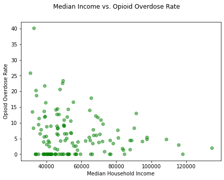

```python
fig, ax = plt.subplots()

ax.scatter(df_op['MedianHouseholdIncome'], df_op['FPOO-Rate'], alpha=0.5, c = 'g')
fig.suptitle('Median Income vs. Opioid Overdose Rate ')
ax.xaxis.set_label_text('Median Household Income')
ax.yaxis.set_label_text('Opioid Overdose Rate')
fig.set_size_inches(7,5)
plt.show()
```

### Some people who start with opioid addictions are reported to transition to heroin use. What is the relationship in Virginia counties between opioid overdoses and heroin overdoses?

The scatterplot of opioid overdose vs herion overdose rates does appear to present a pattern of higher heroin overdoses in the lower range of opioid overdoses which could be evidence to support a hypothesis of opioid acting as a gateway drug to heroin.

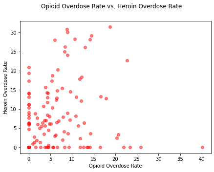

```python
fig, ax = plt.subplots()

ax.scatter(df_op['FPOO-Rate'], df_op['FFHO-Rate'], alpha=0.5, c = 'r')
fig.suptitle('Opioid Overdose Rate vs. Heroin Overdose Rate ')
ax.xaxis.set_label_text('Opioid Overdose Rate')
ax.yaxis.set_label_text('Heroin Overdose Rate')
fig.set_size_inches(7,5)
plt.show()
```

```python
df_prez = pd.read_csv('presidents.csv')
```

```python
df_prez
```

|  | Name | Location | State |
| --- | --- | --- | --- |
| 0 | George Washington | Westmoreland County | Virginia |
| 1 | John Adams | Braintree | Massachusetts |
| 2 | Thomas Jefferson | Shadwell | Virginia |
| 3 | James Madison | Port Conway | Virginia |
| 4 | James Monroe | Monroe Hall | Virginia |
| 5 | Andrew Jackson | Waxhaws Region | South/North Carolina |
| 6 | John Quincy Adams | Braintree | Massachusetts |
| 7 | William Henry Harrison | Charles City County | Virginia |
| 8 | Martin Van Buren | Kinderhook | New York |
| 9 | Zachary Taylor | Barboursville | Virginia |
| 10 | John Tyler | Charles City County | Virginia |
| 11 | James Buchanan | Cove Gap | Pennsylvania |
| 12 | James K. Polk | Pineville | North Carolina |
| 13 | Millard Fillmore | Summerhill | New York |
| 14 | Franklin Pierce | Hillsborough | New Hampshire |
| 15 | Andrew Johnson | Raleigh | North Carolina |
| 16 | Abraham Lincoln | Sinking Spring | Kentucky |
| 17 | Ulysses S. Grant | Point Pleasant | Ohio |
| 18 | Rutherford B. Hayes | Delaware | Ohio |
| 19 | James A. Garfield | Moreland Hills | Ohio |
| 20 | Chester A. Arthur | Fairfield | Vermont |
| 21 | Benjamin Harrison | North Bend | Ohio |
| 22 | Grover Cleveland | Caldwell | New Jersey |
| 23 | William McKinley | Niles | Ohio |
| 24 | Woodrow Wilson | Staunton | Virginia |
| 25 | William H. Taft | Cincinnati | Ohio |
| 26 | Theodore Roosevelt | New York City | New York |
| 27 | Warren G. Harding | Blooming Grove | Ohio |
| 28 | Calvin Coolidge | Plymouth | Vermont |
| 29 | Herbert Hoover | West Branch | Iowa |
| 30 | Franklin D. Roosevelt | Hyde Park | New York |
| 31 | Harry S. Truman | Lamar | Missouri |
| 32 | Dwight D. Eisenhower | Denison | Texas |
| 33 | Lyndon B. Johnson | Stonewall | Texas |
| 34 | Ronald Reagan | Tampico | Illinois |
| 35 | Richard Nixon | Yorba Linda | California |
| 36 | Gerald Ford | Omaha | Nebraska |
| 37 | John F. Kennedy | Brookline | Massachusetts |
| 38 | George H. W. Bush | Milton | Massachusetts |
| 39 | Jimmy Carter | Plains | Georgia |
| 40 | Donald Trump | Queens, New York City | New York |
| 41 | George W. Bush | New Haven | Connecticut |
| 42 | Bill Clinton | Hope | Arkansas |
| 43 | Barack Obama | Honolulu | Hawaii |

```python
df_prez.describe()
```

|  | Name | Location | State |
| --- | --- | --- | --- |
| count | 44 | 44 | 44 |
| unique | 44 | 42 | 21 |
| top | James K. Polk | Charles City County | Virginia |
| freq | 1 | 2 | 8 |

### Which states are associated with the greatest number of United States presidents in terms of the presidents’ birthplaces?

The states with the most U.S. Presidents' birthplace are Virginia, Ohio, New York, and Massachusetts

[figure not shown]

```python
import numpy as np
df_prez.sort_values('State', inplace=True)
x = df_prez['State']
plt.hist(x, bins=15)
plt.title('Histogram of U.S. Presidents and Birth States')
plt.ylabel('Frequency')
plt.xlabel('State')
plt.show()
```

```python
df_cars = pd.read_csv('TOTALNSA.csv')
```

```python
df_cars.head()
```

|  | DATE | TOTALNSA |
| --- | --- | --- |
| 0 | 1976-01-01 | 885.2 |
| 1 | 1976-02-01 | 994.7 |
| 2 | 1976-03-01 | 1243.6 |
| 3 | 1976-04-01 | 1191.2 |
| 4 | 1976-05-01 | 1203.2 |

```python
df_cars.columns
```

```
Index(['DATE', 'TOTALNSA'], dtype='object')
```

```python
df_cars.columns.values
```

```
array(['DATE', 'TOTALNSA'], dtype=object)
```

### How have vehicle sales in the United States varied over time?

The U.S. vehicle sales trend appears to be cyclical and perhaps closely follow overall economic trends in the U.S. I chose a line chart for this time series data for its ease in visualizing the data trend overtime.

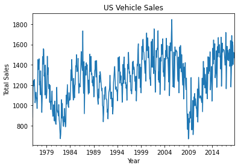

```python
from pandas import read_csv
from matplotlib import pyplot
series = read_csv('TOTALNSA.csv', header=0, index_col=0, parse_dates=True, squeeze=True)
series.plot()
plt.title('US Vehicle Sales')
plt.xlabel('Year')
plt.ylabel('Total Sales')
pyplot.show()
```